# DeepMetrica Customer Segmentation Analysis - Websites Using Crazy Egg

Tugrul Ozsoy

27 Eylül 2020

# 1 Introduction

The data we analyzed consisting of the 5,000 websites using the technology of one of the our secondary competitors Crazy Egg. Domain, Website Language, Global and Local Traffic Rank and Number of Referring Domains are the variables. The dataset is exported from `hunter.io` and enhanced by `Alexa Rank` tool of `SEO Tools for Excel Add-on`.

Crazy Egg is one of the strongest technology giving service in heatmaps and session recording to websites.

Here, you can see some visuals about Crazy Egg:

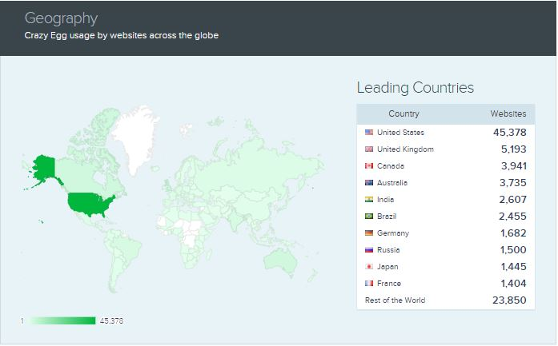

They provide service for almost 100,000 websites across the world. Some of the most leading countries provided after United States, United Kingdom, Canada, Australia are India, Brazil, Germany, and France.

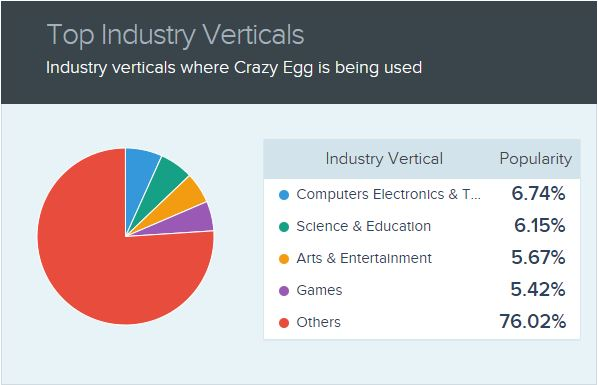

The websites purchased Crazy Egg have verticals mostly like Computer Electronics&Technology, Arts&Entertainment, and Others which can be consisted of News&Media, E-commerce, etc.

[figure not shown]

Crazy Egg is also very popular among the sites having the most monthly visits around the world as Outbrain, Aajtak, or El Mundo.

# 2 Data Analyses

## 2.1 Alexa Ranking of Websites

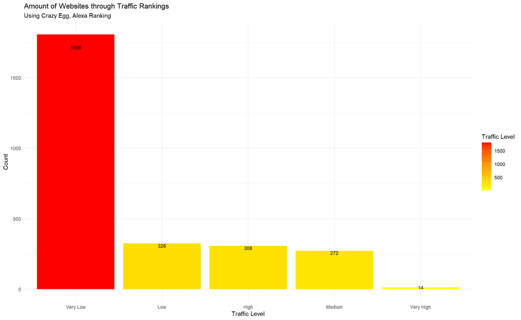

When we group the 2k websites using Crazy Egg by their Alexa rankings. Alexa rankings which show traffic levels are categorized as:

Very High -> Lower than 5000

High -> Between 5000 and 100000

Medium -> Between 100000 and 250000

Low -> Between 250000 and 500000

Very Low -> Higher than 500000

Since our sample data contains the websites which are in a very large interval of 173-10,304,767 Alexa Global Rank, and total number of elements are only 5K; most of the websites stay as outliers.

With the help of this chart, we can deduce that rather than websites having only high traffic levels, domains having least monthly visits and almost non-traffic at all are also eager to demand this kind of service. They prefer Crazy Egg more than we guess to enhance their UX and increase their traffic and clicks. However, it looks like majority gains no benefit still.

## 2.2 Referring Domains

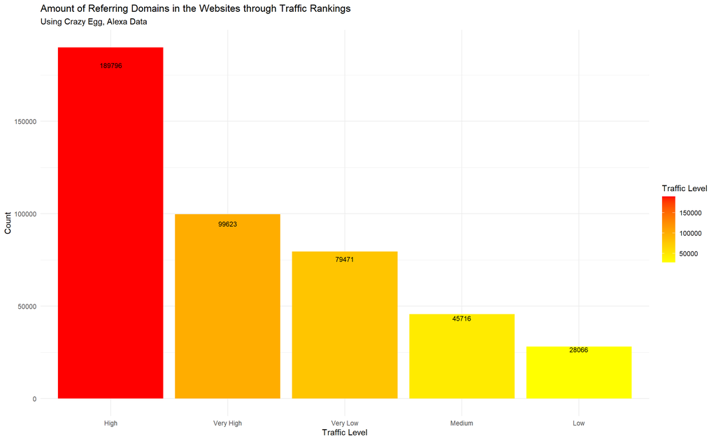

It is the natural result of the correlation between number of referring domains/backlinks and SEO ranking of a website. However, the issue that very low traffic websites have more referring domains than medium is sourced from missing information again.

## 2.3 Language of Websites

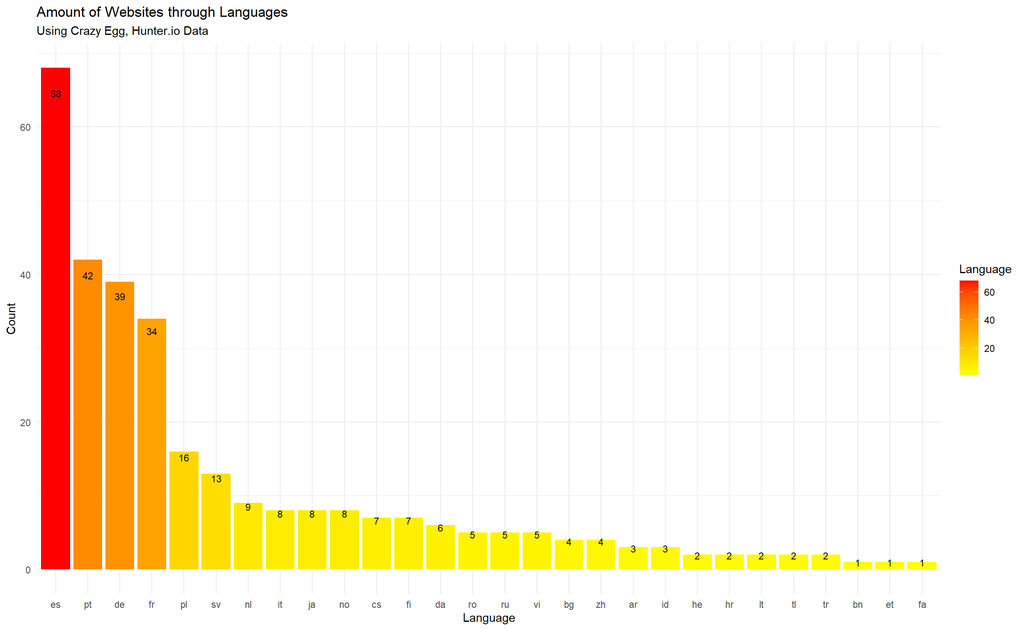

When we group the 5k websites using Crazy Egg by the language used, and when we exclude English to prevent the deviation, we observe that Spanish, Portuguese, German, French are used in most of them. We can deduce that Crazy Egg making sells after United States to the countries as:

Websites of MEXICO, SPAIN and COLOMBIA with high traffic ranking:

`expansion.mx` with Alexa Ranking 11,943 and 194 in Mexico  
`record.com.mx` with Alexa Ranking 12,040 and 367 in Mexico  
`lasexta.com` with Alexa Ranking 13,001 and 276 in Spain  
`vozpopuli.com` with Alexa Ranking 20,962 and 599 in Spain  
`movistar.co` with Alexa Ranking 21,270 and 142 in Colombia

Websites of BRAZIL and ANGOLA with high traffic ranking:

`passeidireto.com` with Alexa Ranking 3,502 and 50 in Brazil  
`estrategiaconcursos.com.br` with Alexa Ranking 7,007 and 162 in Brazil  
`stoodi.com.br` with Alexa Ranking 14,108 and 231 in Brazil  
`klickpages.com.br` with Alexa Ranking 15,890 and 2,119 in Brazil  
`portalangop.co.ao` with Alexa Ranking 25,449 and 36 in Angola

Websites of GERMANY and US with high traffic ranking:

`pnn.de` with Alexa Ranking 70,903 and 1,822 in Germany  
`wirkaufendeinauto.de` with Alexa Ranking 113,286  
`fmca.com` with Alexa Ranking 195,919 and 48,858 in United States  
`kunstpark-shop.de` with Alexa Ranking 199,096  
`spyoptic.com` with Alexa Ranking 221,574 and 86,485 in United States

Websites of FRANCE, US and INDIA with high traffic ranking:

`discovery.com` with Alexa Ranking 19,137 and 5,991 in US  
`myfax.com` with Alexa Ranking 54,974  
`tajhotels.com` with Alexa Ranking 60,103 and 5,109 in India  
`mindlabpro.com` with Alexa Ranking 103,158 and 42,367 in United States  
`ademe.fr` with Alexa Ranking 107,819 and 2,092 in France

## 2.4 Verticals of Websites

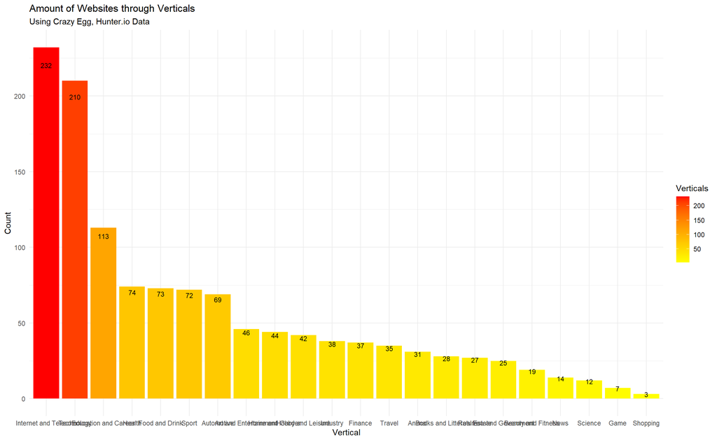

When we look at the verticals of the websites using Crazy Egg technology, we observe that most of them are Internet&Telecom, Technology or Education&Career. To focus on these categories of websites in terms of marketing at first step could be ideal for DeepMetrica.